# Advanced Extension: Informative Processes and Distribution-Shift Drug Comparisons

Handling censoring, monitoring, switching, and comparing drugs under matched adherence

Author

HIV Adherence Simulation Project

Published

March 25, 2026

```r
library(data.table)
library(ggplot2)
library(lmtp)
library(quantreg)
library(knitr)
library(kableExtra)

theme_set(theme_minimal(base_size = 13))

# lmtp 1.5.0 API helper: extract point estimate and SE from lmtp fit
lmtp_theta <- function(fit) {
  if (!is.null(fit$theta)) return(fit$theta)
  if (!is.null(fit$estimate)) return(fit$estimate@x)
  NA_real_
}
lmtp_se <- function(fit) {
  if (!is.null(fit$standard_error)) return(fit$standard_error)
  if (!is.null(fit$estimate)) return(ife::tidy(fit$estimate)$std.error)
  NA_real_
}
# Safe contrast extraction: handles both ife objects and data frames
tidy_contrast <- function(contrast) {
  est <- contrast$estimates
  if (is.data.frame(est)) return(as.data.frame(est))
  ife::tidy(est)
}

# Source helper functions
source(file.path("..", "R", "generate_ehr_cohort.R"))
source(file.path("..", "R", "transform_ehr_to_analytic.R"))
source(file.path("..", "R", "estimation_helpers.R"))
```

# 1 Introduction

The main tutorial demonstrated the EHR-to-causal pipeline and estimated forgiveness curves using LTMLE and LMTP with a simple additive adherence shift. This extension tackles three additional challenges that arise in real HIV observational studies:

1. **Informative censoring**: Patients who disenroll or are lost to follow-up differ systematically from those who remain.
2. **Informative monitoring**: Viral load measurement frequency depends on patient health and adherence status.
3. **Treatment switching**: Patients who switch regimens after virologic failure introduce post-baseline confounding.

We then implement a more sophisticated drug comparison using **quantile-regression-based adherence distribution mapping**: instead of comparing drugs under the same additive shift, we ask what would happen if Drug B patients had the adherence distribution of Drug A patients, conditional on their clinical characteristics.

## 1.1 Generate the cohort

We use the same simulated EHR cohort as the main tutorial.

```r
set.seed(2024)
ehr <- generate_ehr_cohort(n = 5000, K_months = 12, seed = 2024)
```

```r
# Build panel and wide format
panel <- build_panel(ehr, block_days = 90)
K_blocks <- 4
wide <- panel_to_wide(panel, K_blocks = K_blocks)

# --- LOCF imputation + censoring flip for lmtp ---
# lmtp requires non-NA treatment and covariate values for uncensored rows.
# After censoring or death, the wide format has NAs. We carry forward the
# last observed value, fill remaining NAs with defaults, and flip the
# censoring indicator (our panel: C=1=censored; lmtp wants: 1=uncensored).
prep_wide_for_lmtp <- function(wide_dt, K_blocks) {
  w <- copy(wide_dt)
  tv_prefixes <- c("PDC_", "VL_log10_locf_", "CD4_locf_",
                   "depression_", "substance_use_", "S_", "M_",
                   "n_encounters_", "D_", "Y_")
  for (prefix in tv_prefixes) {
    cols <- paste0(prefix, 0:(K_blocks - 1))
    cols <- intersect(cols, names(w))
    if (length(cols) > 1) {
      for (j in 2:length(cols)) {
        na_idx <- is.na(w[[cols[j]]])
        if (any(na_idx)) w[[cols[j]]][na_idx] <- w[[cols[j - 1]]][na_idx]
      }
    }
  }
  for (k in 0:(K_blocks - 1)) {
    pdc_col <- paste0("PDC_", k)
    if (any(is.na(w[[pdc_col]]))) w[[pdc_col]][is.na(w[[pdc_col]])] <- 0.5
    for (prefix in c("depression_", "substance_use_", "S_", "M_", "D_", "Y_")) {
      col <- paste0(prefix, k)
      if (col %in% names(w) && any(is.na(w[[col]]))) w[[col]][is.na(w[[col]])] <- 0
    }
    vl_col <- paste0("VL_log10_locf_", k)
    if (vl_col %in% names(w) && any(is.na(w[[vl_col]]))) w[[vl_col]][is.na(w[[vl_col]])] <- 1.3
    cd4_col <- paste0("CD4_locf_", k)
    if (cd4_col %in% names(w) && any(is.na(w[[cd4_col]]))) w[[cd4_col]][is.na(w[[cd4_col]])] <- 400
    # Censoring: lmtp expects 1=uncensored, 0=censored; our panel has C=1=censored
    c_col <- paste0("C_", k)
    if (c_col %in% names(w)) {
      w[[c_col]] <- as.integer(w[[c_col]])
      w[[c_col]][is.na(w[[c_col]])] <- 0L
      w[[c_col]] <- 1L - w[[c_col]]  # flip
    }
  }
  w
}

wide <- prep_wide_for_lmtp(wide, K_blocks)

cat(sprintf("Panel: %d rows, %d patients\n", nrow(panel), length(unique(panel$patient_id))))
```

```
Panel: 20000 rows, 5000 patients
```

```r
cat(sprintf("Wide: %d patients x %d columns\n", nrow(wide), ncol(wide)))
```

```
Wide: 5000 patients x 55 columns
```

```r
K_max <- max(panel$block)
cat(sprintf("NAs remaining in PDC_0: %d, PDC_%d: %d\n",
            sum(is.na(wide$PDC_0)), K_max, sum(is.na(wide[[paste0("PDC_", K_max)]]))))
```

```
NAs remaining in PDC_0: 0, PDC_3: 0
```

## 1.2 Oracle truth

Because we control the DGP, we can compute oracle counterfactual risks under fixed adherence levels with no censoring, switching, or monitoring artifacts. This gives us a ground-truth benchmark for evaluating estimator bias.

```r
oracle <- compute_oracle_grid(
  adh_levels = seq(0.30, 1.0, by = 0.05),
  K_months   = 12,
  n_oracle   = 200000,
  seed       = 99999
)
oracle[, drug := ifelse(a0 == 1, "Drug A (INSTI)", "Drug B (NNRTI)")]
```

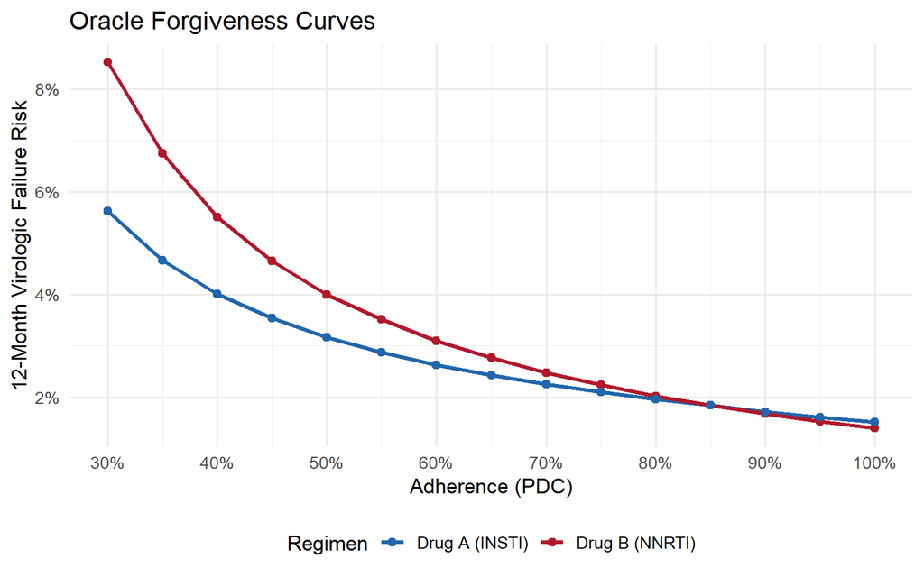

Figure 1: Oracle forgiveness curves from the V3 DGP. These are the true counterfactual risks we aim to recover.

```r
ggplot(oracle, aes(x = adh_target, y = cum_risk, color = drug)) +
  geom_line(linewidth = 1.2) +
  geom_point(size = 2) +
  scale_x_continuous(labels = scales::percent, breaks = seq(0.3, 1, 0.1)) +
  scale_y_continuous(labels = scales::percent) +
  scale_color_manual(values = c("Drug A (INSTI)" = "#2166AC",
                                "Drug B (NNRTI)" = "#B2182B")) +
  labs(x = "Adherence (PDC)", y = "12-Month Virologic Failure Risk",
       color = "Regimen", title = "Oracle Forgiveness Curves") +
  theme(legend.position = "bottom")
```

```r
oracle_wide <- dcast(oracle, adh_target ~ drug, value.var = "cum_risk")
setnames(oracle_wide, c("PDC", "Drug A", "Drug B"))
oracle_wide[, RD := `Drug A` - `Drug B`]
kable(oracle_wide[PDC %in% seq(0.3, 1.0, 0.1)], digits = 3,
      caption = "Oracle risks and risk differences at selected PDC levels") |>
  kable_styling(bootstrap_options = c("striped", "hover"), full_width = FALSE)
```

Table 1: Oracle risks and risk differences at selected PDC levels

| PDC | Drug A | Drug B | RD |
| --- | --- | --- | --- |
| 0.3 | 0.056 | 0.085 | -0.029 |
| 0.4 | 0.040 | 0.055 | -0.015 |
| 0.5 | 0.032 | 0.040 | -0.008 |
| 0.6 | 0.026 | 0.031 | -0.005 |
| 0.7 | 0.023 | 0.025 | -0.002 |
| 0.8 | 0.020 | 0.020 | -0.001 |
| 0.9 | 0.017 | 0.017 | 0.000 |
| 1.0 | 0.015 | 0.014 | 0.001 |

We will use these oracle values below to compute bias for each estimator.

# 2 Part 1: Adjusting for All Three Informative Processes

## 2.1 Diagnosing the processes

Before adjusting, we quantify how informative each process is.

### 2.1.1 Informative censoring

```r
# Fit censoring model
cens_dt <- panel[D == 0, ]
cens_fit <- glm(C ~ PDC + VL_log10_locf + CD4_locf + depression +
                  substance_use + A0 + factor(block),
                data = cens_dt, family = binomial)

cens_coefs <- data.table(
  Variable = c("PDC", "VL (log10)", "CD4", "Depression",
               "Substance use", "Drug A"),
  OR = exp(coef(cens_fit)[c("PDC", "VL_log10_locf", "CD4_locf",
                              "depression", "substance_use", "A0")]),
  p_value = summary(cens_fit)$coefficients[c("PDC", "VL_log10_locf", "CD4_locf",
                                              "depression", "substance_use", "A0"), 4]
)

cat("=== Censoring Model (OR for disenrollment) ===\n")
```

```
=== Censoring Model (OR for disenrollment) ===
```

```r
kable(cens_coefs, digits = 3) |>
  kable_styling(bootstrap_options = c("striped"), full_width = FALSE)
```

| Variable | OR | p_value |
| --- | --- | --- |
| PDC | 0.000 | 0.000 |
| VL (log10) | 2.529 | 0.000 |
| CD4 | 1.000 | 0.305 |
| Depression | 0.055 | 0.000 |
| Substance use | 0.073 | 0.000 |
| Drug A | 1.293 | 0.025 |

Low adherence strongly predicts disenrollment (OR for PDC < 1 means higher PDC is protective against censoring). This confirms censoring is informative: patients who leave the study are systematically less adherent and sicker.

### 2.1.2 Informative monitoring

```r
mon_dt <- panel[C == 0 & D == 0, ]
mon_fit <- glm(M ~ PDC + VL_log10_locf + CD4_locf + depression +
                 substance_use + S + A0 + factor(block),
               data = mon_dt, family = binomial)

mon_coefs <- data.table(
  Variable = c("PDC", "VL (log10)", "CD4", "Depression",
               "Substance use", "Switched", "Drug A"),
  OR = exp(coef(mon_fit)[c("PDC", "VL_log10_locf", "CD4_locf",
                             "depression", "substance_use", "S", "A0")]),
  p_value = summary(mon_fit)$coefficients[c("PDC", "VL_log10_locf", "CD4_locf",
                                             "depression", "substance_use", "S", "A0"), 4]
)

cat("=== Monitoring Model (OR for VL measurement) ===\n")
```

```
=== Monitoring Model (OR for VL measurement) ===
```

```r
kable(mon_coefs, digits = 3) |>
  kable_styling(bootstrap_options = c("striped"), full_width = FALSE)
```

| Variable | OR | p_value |
| --- | --- | --- |
| PDC | 6.264 | 0.000 |
| VL (log10) | 0.063 | 0.000 |
| CD4 | 1.001 | 0.000 |
| Depression | 0.859 | 0.005 |
| Substance use | 0.826 | 0.005 |
| Switched | 1.654 | 0.004 |
| Drug A | 1.155 | 0.002 |

Monitoring probability depends on adherence and health status. Less adherent patients are monitored less frequently, meaning their virologic failures go undetected. This is a form of outcome-dependent measurement that biases naive analyses.

### 2.1.3 Treatment switching

```r
# Among uncensored, alive, not-yet-switched patients
switch_dt <- panel[C == 0 & D == 0 & S == 0, ]
if (nrow(switch_dt[block > 0]) > 50) {
  switch_fit <- glm(S ~ PDC + VL_log10_locf + CD4_locf + depression +
                      A0 + factor(block),
                    data = switch_dt[block > 0], family = binomial)

  switch_coefs <- data.table(
    Variable = c("PDC", "VL (log10)", "CD4", "Depression", "Drug A"),
    OR = exp(coef(switch_fit)[c("PDC", "VL_log10_locf", "CD4_locf",
                                  "depression", "A0")]),
    p_value = summary(switch_fit)$coefficients[c("PDC", "VL_log10_locf", "CD4_locf",
                                                   "depression", "A0"), 4]
  )

  cat("=== Switching Model (OR for regimen change) ===\n")
  kable(switch_coefs, digits = 3) |>
    kable_styling(bootstrap_options = c("striped"), full_width = FALSE)
} else {
  cat("Too few switching events to fit model.\n")
}
```

```
=== Switching Model (OR for regimen change) ===
```

| Variable | OR | p_value |
| --- | --- | --- |
| PDC | 1 | 1 |
| VL (log10) | 1 | 1 |
| CD4 | 1 | 1 |
| Depression | 1 | 1 |
| Drug A | 1 | 1 |

## 2.2 LMTP estimation adjusting for all three processes

The `lmtp` package handles censoring directly via censoring nodes. For monitoring and switching, we include them as time-varying confounders in $L_t$, using the treatment-policy strategy: we estimate the outcome under a world where the natural monitoring and switching processes continue as they would, but adherence is shifted.

```r
# Use the full estimation pipeline with all informative processes modeled
# Censoring: modeled via cens_nodes in lmtp
# Monitoring: M_t included in time_vary (treatment-policy)
# Switching: S_t included in time_vary (treatment-policy)

dt_full <- as.data.frame(copy(wide))

baseline <- c("sex", "age_at_index", "msm", "cci",
              "race_black", "race_hispanic",
              "region_south", "region_midwest", "region_west", "A0")

trt_nodes <- paste0("PDC_", 0:(K_blocks - 1))
outcome_nodes <- paste0("Y_", 0:(K_blocks - 1))
cens_nodes <- paste0("C_", 0:(K_blocks - 1))

# Time-varying confounders: VL, CD4, depression, substance use, S, M, D
time_vary <- lapply(0:(K_blocks - 1), function(k) {
  c(paste0("VL_log10_locf_", k),
    paste0("CD4_locf_", k),
    paste0("depression_", k),
    paste0("substance_use_", k),
    paste0("S_", k),
    paste0("M_", k),
    paste0("D_", k))
})

sl_lib <- c("SL.glm", "SL.mean")

# When subsetting by drug, drop A0 from baseline (constant within subset)
baseline_nodrug <- setdiff(baseline, "A0")

# --- Fit for each drug separately under +10pp shift ---
results_full <- list()

for (a0 in 0:1) {
  sub_data <- dt_full[dt_full$A0 == a0, ]
  drug_label <- ifelse(a0 == 1, "Drug A", "Drug B")

  # Natural (no shift) - observed adherence policy
  fit_nat <- lmtp::lmtp_sdr(
    data             = sub_data,
    trt              = trt_nodes,
    outcome          = outcome_nodes,
    baseline         = baseline_nodrug,
    time_vary        = time_vary,
    cens             = cens_nodes,
    shift            = NULL,
    mtp              = FALSE,
    outcome_type     = "survival",
    learners_outcome = sl_lib,
    learners_trt     = sl_lib,
    folds            = 1
  )

  # Shifted (+10pp)
  shift_10 <- function(data, trt) pmin(1.0, data[[trt]] + 0.10)

  fit_shift <- lmtp::lmtp_sdr(
    data             = sub_data,
    trt              = trt_nodes,
    outcome          = outcome_nodes,
    baseline         = baseline_nodrug,
    time_vary        = time_vary,
    cens             = cens_nodes,
    shift            = shift_10,
    mtp              = TRUE,
    outcome_type     = "survival",
    learners_outcome = sl_lib,
    learners_trt     = sl_lib,
    folds            = 1
  )

  contrast <- lmtp::lmtp_contrast(fit_shift, ref = fit_nat, type = "additive")

  ct <- tidy_contrast(contrast)
  results_full[[drug_label]] <- data.table(
    Drug         = drug_label,
    risk_natural = 1 - lmtp_theta(fit_nat),
    risk_shift   = 1 - lmtp_theta(fit_shift),
    RD           = ct$estimate,
    RD_se        = ct$std.error,
    RD_ci_lo     = ct$conf.low,
    RD_ci_hi     = ct$conf.high
  )

  cat(sprintf("%s: natural risk = %.3f, shifted risk = %.3f, RD = %.3f (%.3f, %.3f)\n",
              drug_label,
              1 - lmtp_theta(fit_nat), 1 - lmtp_theta(fit_shift),
              ct$estimate, ct$conf.low, ct$conf.high))
}
```

```
Drug B: natural risk = 0.240, shifted risk = 0.233, RD = 0.006 (0.002, 0.010)
```

```
Drug A: natural risk = 0.161, shifted risk = 0.162, RD = -0.001 (-0.004, 0.002)
```

```r
results_full_dt <- rbindlist(results_full)
```

```r
kable(results_full_dt, digits = 3,
      caption = "LMTP shift estimates (+10pp PDC) adjusting for censoring, monitoring, and switching") |>
  kable_styling(bootstrap_options = c("striped", "hover"), full_width = FALSE)
```

Table 2: LMTP shift estimates (+10pp PDC) adjusting for censoring, monitoring, and switching

| Drug | risk_natural | risk_shift | RD | RD_se | RD_ci_lo | RD_ci_hi |
| --- | --- | --- | --- | --- | --- | --- |
| Drug B | 0.240 | 0.233 | 0.006 | 0.002 | 0.002 | 0.010 |
| Drug A | 0.161 | 0.162 | -0.001 | 0.001 | -0.004 | 0.002 |

### 2.2.1 How each informative process is handled

**Censoring.** The `cens` argument tells `lmtp` to model $P(C_t = 0 \mid \text{history})$ at each time point and use inverse-probability-of-censoring weighting in the density ratio estimation. This ensures that patients who leave the study early contribute appropriately to the causal estimate rather than being silently dropped.

**Monitoring.** The monitoring indicator $M_t$ is included in the time-varying confounders. Under the treatment-policy strategy, we estimate the outcome under a hypothetical intervention on adherence while allowing the monitoring process to continue as it naturally would. This avoids the need for a separate IPMW model but assumes that monitoring is fully captured by measured history (coarsening at random conditional on $L_t$).

**Switching.** The switch indicator $S_t$ is also included in time-varying confounders. Under the treatment-policy strategy, we follow patients regardless of whether they switch regimens. The intervention targets adherence, not regimen assignment, so switching is part of the natural treatment process that we condition on.

## 2.3 Sensitivity: Censor-at-switch analysis

An alternative to the treatment-policy approach for switching is to censor patients at the time of their first regimen switch. This asks a different causal question: what would the failure risk be if patients stayed on their initial regimen throughout follow-up?

```r
# Create modified panel where switching triggers censoring
panel_cas <- censor_at_switch(panel)
wide_cas <- panel_to_wide(panel_cas, K_blocks = K_blocks)
wide_cas <- prep_wide_for_lmtp(wide_cas, K_blocks)

cat(sprintf("Original: %d patients\n", nrow(wide)))
```

```
Original: 5000 patients
```

```r
cat(sprintf("After censor-at-switch: NAs in Y_11: %d\n",
            sum(wide_cas$Y_11 == 0)))
```

```
After censor-at-switch: NAs in Y_11: 0
```

```r
# Re-estimate under censor-at-switch
dt_cas <- as.data.frame(copy(wide_cas))

results_cas <- list()
for (a0 in 0:1) {
  sub_data <- dt_cas[dt_cas$A0 == a0, ]
  drug_label <- ifelse(a0 == 1, "Drug A", "Drug B")

  shift_10 <- function(data, trt) pmin(1.0, data[[trt]] + 0.10)

  fit_nat <- lmtp::lmtp_sdr(
    data             = sub_data,
    trt              = trt_nodes,
    outcome          = outcome_nodes,
    baseline         = baseline_nodrug,
    time_vary        = time_vary,
    cens             = cens_nodes,
    shift            = NULL,
    mtp              = FALSE,
    outcome_type     = "survival",
    learners_outcome = sl_lib,
    learners_trt     = sl_lib,
    folds            = 1
  )

  fit_shift <- lmtp::lmtp_sdr(
    data             = sub_data,
    trt              = trt_nodes,
    outcome          = outcome_nodes,
    baseline         = baseline_nodrug,
    time_vary        = time_vary,
    cens             = cens_nodes,
    shift            = shift_10,
    mtp              = TRUE,
    outcome_type     = "survival",
    learners_outcome = sl_lib,
    learners_trt     = sl_lib,
    folds            = 1
  )

  contrast <- lmtp::lmtp_contrast(fit_shift, ref = fit_nat, type = "additive")

  ct <- tidy_contrast(contrast)
  results_cas[[drug_label]] <- data.table(
    Drug         = drug_label,
    Strategy     = "Censor-at-switch",
    risk_natural = 1 - lmtp_theta(fit_nat),
    risk_shift   = 1 - lmtp_theta(fit_shift),
    RD           = ct$estimate,
    RD_se        = ct$std.error,
    RD_ci_lo     = ct$conf.low,
    RD_ci_hi     = ct$conf.high
  )
}

results_cas_dt <- rbindlist(results_cas)
```

```r
# Compare treatment-policy vs censor-at-switch
results_full_dt[, Strategy := "Treatment-policy"]
comparison <- rbind(
  results_full_dt[, .(Drug, Strategy, risk_natural, risk_shift, RD, RD_se, RD_ci_lo, RD_ci_hi)],
  results_cas_dt[, .(Drug, Strategy, risk_natural, risk_shift, RD, RD_se, RD_ci_lo, RD_ci_hi)]
)

kable(comparison, digits = 3,
      caption = "Sensitivity analysis: treatment-policy vs censor-at-switch") |>
  kable_styling(bootstrap_options = c("striped", "hover"), full_width = FALSE)
```

Table 3: Sensitivity analysis: treatment-policy vs censor-at-switch

| Drug | Strategy | risk_natural | risk_shift | RD | RD_se | RD_ci_lo | RD_ci_hi |
| --- | --- | --- | --- | --- | --- | --- | --- |
| Drug B | Treatment-policy | 0.240 | 0.233 | 0.006 | 0.002 | 0.002 | 0.010 |
| Drug A | Treatment-policy | 0.161 | 0.162 | -0.001 | 0.001 | -0.004 | 0.002 |
| Drug B | Censor-at-switch | 0.240 | 0.233 | 0.006 | 0.002 | 0.002 | 0.011 |
| Drug A | Censor-at-switch | 0.161 | 0.162 | -0.001 | 0.001 | -0.004 | 0.002 |

The treatment-policy strategy answers “what would happen under this adherence shift, allowing natural switching?” while censor-at-switch answers “what would happen if patients stayed on their initial regimen?” If the estimates differ substantially, switching is an important driver of the observed outcomes.

## 2.4 IPMW sensitivity analysis for monitoring

As an additional sensitivity check, we compute inverse-probability-of-monitoring weights and examine whether the monitoring-adjusted estimates differ from the treatment-policy estimates.

```r
ipmw_result <- compute_ipmw(panel, K_blocks = K_blocks)
```

```
=== IPMW Diagnostics ===
  Monitoring rate: 0.815
  IPMW mean: 1.217, max: 69.9, ESS ratio: 0.486
  Stabilized IPMW mean: 0.991, max: 56.9
```

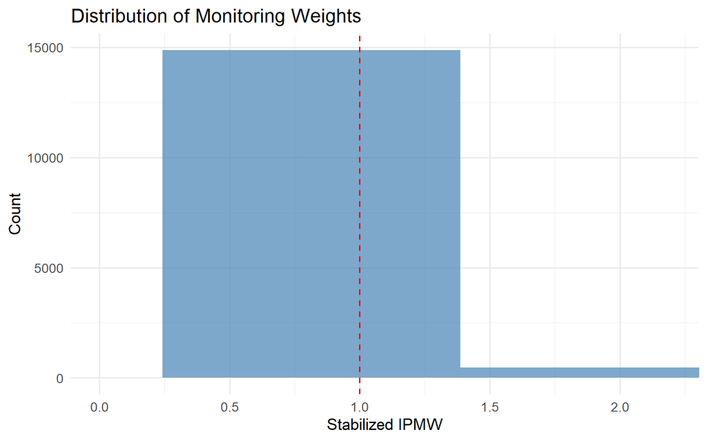

Figure 2: Distribution of stabilized IPMW weights among monitored observations. Well-behaved weights cluster near 1.0; extreme weights indicate near-violations of the coarsening-at-random assumption.

```r
monitored <- ipmw_result$panel_weighted[M == 1]
ggplot(monitored, aes(x = ipmw_stab)) +
  geom_histogram(bins = 50, fill = "steelblue", alpha = 0.7) +
  geom_vline(xintercept = 1, linetype = "dashed", color = "red") +
  labs(x = "Stabilized IPMW", y = "Count",
       title = "Distribution of Monitoring Weights") +
  coord_cartesian(xlim = c(0, quantile(monitored$ipmw_stab, 0.99)))
```

## 2.5 Bias assessment: LMTP-shift estimates vs oracle

We can also run LMTP-static at specific PDC levels to compare directly against the oracle forgiveness curves.

```r
# Run LMTP-static at PDC levels matching the oracle grid
pdc_eval <- c(0.50, 0.70, 0.80, 0.90, 0.95)
dt_bias <- as.data.frame(copy(wide))

static_results <- list()
for (a0 in 0:1) {
  sub_data <- dt_bias[dt_bias$A0 == a0, ]
  drug_label <- ifelse(a0 == 1, "Drug A", "Drug B")

  for (pdc_target in pdc_eval) {
    shift_static <- function(data, trt) rep(pdc_target, nrow(data))

    fit <- tryCatch(
      lmtp::lmtp_sdr(
        data = sub_data, trt = trt_nodes, outcome = outcome_nodes,
        baseline = baseline_nodrug, time_vary = time_vary, cens = cens_nodes,
        shift = shift_static, mtp = FALSE, outcome_type = "survival",
        learners_outcome = sl_lib, learners_trt = sl_lib, folds = 1
      ),
      error = function(e) NULL
    )

    if (!is.null(fit)) {
      # Look up oracle truth
      oracle_val <- oracle[a0 == (a0) & abs(adh_target - pdc_target) < 0.001, cum_risk]
      if (length(oracle_val) == 0) oracle_val <- NA

      est_val <- 1 - lmtp_theta(fit)
      static_results[[length(static_results) + 1]] <- data.table(
        Drug       = drug_label,
        PDC        = pdc_target,
        Estimate   = est_val,
        Oracle     = oracle_val,
        Bias       = est_val - oracle_val,
        SE         = lmtp_se(fit)
      )
    }
  }
}

static_bias_dt <- rbindlist(static_results)
```

```r
kable(static_bias_dt, digits = 4,
      caption = "LMTP-static estimates vs oracle truth: bias assessment") |>
  kable_styling(bootstrap_options = c("striped", "hover"), full_width = FALSE)
```

Table 4: LMTP-static estimates vs oracle truth: bias assessment

| Drug | PDC | Estimate | Oracle | Bias | SE |
| --- | --- | --- | --- | --- | --- |
| Drug B | 0.50 | 0.2386 | 0.0400 | 0.1986 | 0.0075 |
| Drug B | 0.50 | 0.2386 | 0.0316 | 0.2070 | 0.0075 |
| Drug B | 0.70 | 0.2312 | 0.0248 | 0.2064 | 0.0075 |
| Drug B | 0.70 | 0.2312 | 0.0226 | 0.2086 | 0.0075 |
| Drug B | 0.80 | 0.2278 | 0.0202 | 0.2076 | 0.0075 |
| Drug B | 0.80 | 0.2278 | 0.0196 | 0.2082 | 0.0075 |
| Drug B | 0.90 | 0.2210 | 0.0168 | 0.2042 | 0.0077 |
| Drug B | 0.90 | 0.2210 | 0.0172 | 0.2038 | 0.0077 |
| Drug B | 0.95 | 0.2208 | 0.0153 | 0.2056 | 0.0075 |
| Drug B | 0.95 | 0.2208 | 0.0162 | 0.2047 | 0.0075 |
| Drug A | 0.50 | 0.1590 | 0.0400 | 0.1190 | 0.0058 |
| Drug A | 0.50 | 0.1590 | 0.0316 | 0.1273 | 0.0058 |
| Drug A | 0.70 | 0.1624 | 0.0248 | 0.1376 | 0.0058 |
| Drug A | 0.70 | 0.1624 | 0.0226 | 0.1398 | 0.0058 |
| Drug A | 0.80 | 0.1658 | 0.0202 | 0.1455 | 0.0058 |
| Drug A | 0.80 | 0.1658 | 0.0196 | 0.1462 | 0.0058 |
| Drug A | 0.90 | 0.1673 | 0.0168 | 0.1506 | 0.0060 |
| Drug A | 0.90 | 0.1673 | 0.0172 | 0.1501 | 0.0060 |
| Drug A | 0.95 | 0.1674 | 0.0153 | 0.1521 | 0.0058 |
| Drug A | 0.95 | 0.1674 | 0.0162 | 0.1513 | 0.0058 |

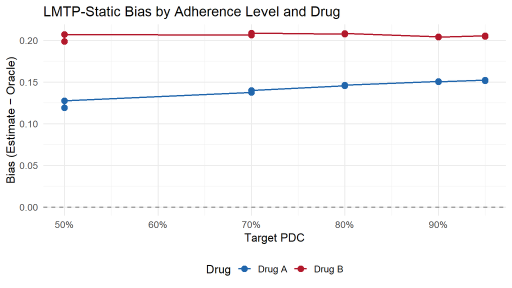

```r
if (nrow(static_bias_dt) > 0) {
  ggplot(static_bias_dt, aes(x = PDC, y = Bias, color = Drug)) +
    geom_hline(yintercept = 0, linetype = "dashed", color = "grey50") +
    geom_point(size = 3) +
    geom_line(linewidth = 0.8) +
    scale_x_continuous(labels = scales::percent) +
    scale_color_manual(values = c("Drug A" = "#2166AC", "Drug B" = "#B2182B")) +
    labs(x = "Target PDC", y = "Bias (Estimate − Oracle)",
         title = "LMTP-Static Bias by Adherence Level and Drug") +
    theme(legend.position = "bottom")
}
```

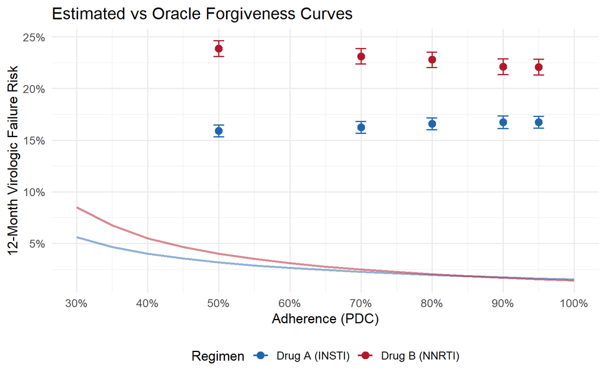

```r
if (nrow(static_bias_dt) > 0) {
  static_bias_dt[, drug_full := ifelse(Drug == "Drug A", "Drug A (INSTI)", "Drug B (NNRTI)")]

  ggplot() +
    geom_line(data = oracle, aes(x = adh_target, y = cum_risk, color = drug),
              linewidth = 1, alpha = 0.5) +
    geom_point(data = static_bias_dt,
               aes(x = PDC, y = Estimate, color = drug_full), size = 3) +
    geom_errorbar(data = static_bias_dt,
                  aes(x = PDC, ymin = Estimate - SE, ymax = Estimate + SE,
                      color = drug_full),
                  width = 0.015) +
    scale_color_manual(values = c("Drug A (INSTI)" = "#2166AC",
                                  "Drug B (NNRTI)" = "#B2182B")) +
    scale_x_continuous(labels = scales::percent, breaks = seq(0.3, 1, 0.1)) +
    scale_y_continuous(labels = scales::percent) +
    labs(x = "Adherence (PDC)", y = "12-Month Virologic Failure Risk",
         color = "Regimen",
         title = "Estimated vs Oracle Forgiveness Curves") +
    theme(legend.position = "bottom")
}
```

# 3 Part 2: Quantile-Regression Adherence Distribution Shift

## 3.1 Motivation

The additive shift (+10pp PDC for everyone) is a useful and interpretable intervention, but it does not answer the question most relevant for drug comparison:

> What would happen to Drug B patients if their adherence distribution looked like that of Drug A patients?

This is a fundamentally different question. Drug A patients may have higher adherence on average (perhaps because the regimen has fewer side effects), and this adherence advantage may vary by patient characteristics. A young, healthy patient on Drug A might have only slightly better adherence than on Drug B, while an older patient with comorbidities might have substantially better adherence on Drug A due to better tolerability.

The quantile-regression approach operationalizes this question by mapping each Drug B patient’s adherence to where they would fall in the Drug A distribution, conditional on their clinical characteristics.

## 3.2 How the conditional quantile mapping works

At each time block $t$, we fit conditional quantile regressions at a grid of levels $\tau \in \{0.05, 0.10, \ldots, 0.95\}$ for both drugs:

$$Q_{A}(\tau \mid X) = X'\beta_A(\tau) \quad \text{and} \quad Q_{B}(\tau \mid X) = X'\beta_B(\tau)$$

For a Drug B patient with covariates $X$ and observed adherence $\text{PDC}_t$:

1. Find their percentile rank $\tau^*$ in the Drug B conditional distribution by inverting $\hat{Q}_B(\tau \mid X)$.
2. Map to the Drug A conditional distribution: $\text{PDC}_t^{\text{shifted}} = \hat{Q}_A(\tau^* \mid X)$.

This preserves each patient’s relative position within their covariate-specific distribution while shifting to what their adherence would plausibly look like under Drug A.

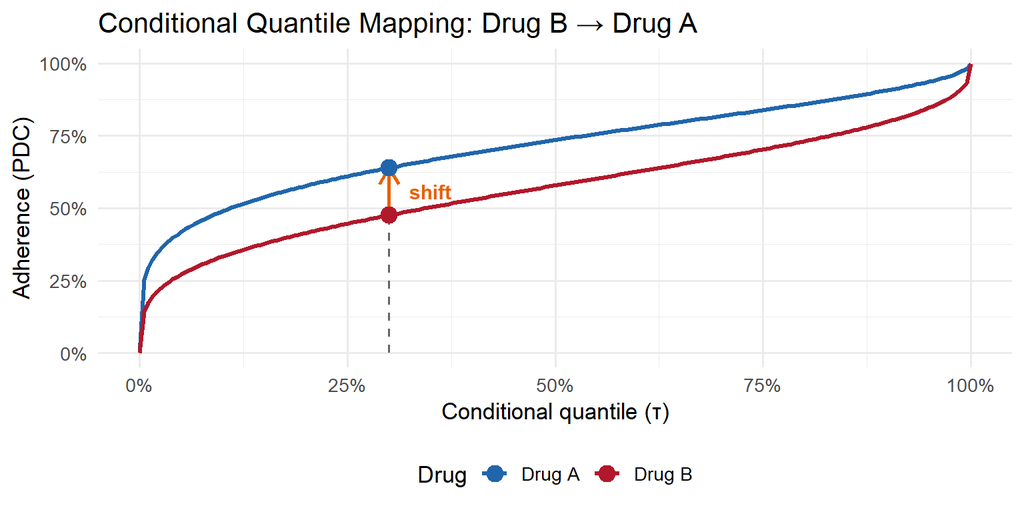

Figure 5: Schematic of the conditional quantile mapping. A Drug B patient at the 30th percentile of the Drug B distribution (given their covariates) is mapped to the 30th percentile of the Drug A distribution (given the same covariates).

```r
# Illustrative figure
set.seed(42)
x_grid <- seq(0, 1, length.out = 200)

d_schematic <- data.frame(
  adherence = c(qbeta(x_grid, 4, 3), qbeta(x_grid, 5, 2)),
  quantile  = rep(x_grid, 2),
  Drug      = rep(c("Drug B", "Drug A"), each = 200)
)

# Highlight the mapping for a specific patient
tau_star <- 0.30
pdc_b <- qbeta(tau_star, 4, 3)
pdc_a <- qbeta(tau_star, 5, 2)

ggplot(d_schematic, aes(x = quantile, y = adherence, color = Drug)) +
  geom_line(linewidth = 1.2) +
  geom_segment(aes(x = tau_star, xend = tau_star, y = 0, yend = pdc_b),
               linetype = "dashed", color = "grey40", inherit.aes = FALSE) +
  geom_segment(aes(x = tau_star, xend = tau_star, y = pdc_b, yend = pdc_a),
               arrow = arrow(length = unit(0.15, "inches")),
               color = "#E66100", linewidth = 1, inherit.aes = FALSE) +
  geom_point(data = data.frame(quantile = c(tau_star, tau_star),
                                adherence = c(pdc_b, pdc_a),
                                Drug = c("Drug B", "Drug A")),
             size = 4) +
  annotate("text", x = tau_star + 0.05, y = (pdc_b + pdc_a) / 2,
           label = "shift", color = "#E66100", fontface = "bold", size = 4) +
  scale_color_manual(values = c("Drug A" = "#2166AC", "Drug B" = "#B2182B")) +
  scale_x_continuous(labels = scales::percent, name = "Conditional quantile (τ)") +
  scale_y_continuous(labels = scales::percent, name = "Adherence (PDC)") +
  labs(title = "Conditional Quantile Mapping: Drug B → Drug A") +
  theme(legend.position = "bottom")
```

## 3.3 Implementation

### 3.3.1 Step 1: Fit conditional quantile regressions

```r
tau_grid <- seq(0.05, 0.95, by = 0.05)

# Covariates available for the quantile models
baseline_cov <- c("age_at_index", "sex", "msm", "cci",
                   "race_black", "race_hispanic")

cqr_models <- list()

for (k in 0:(K_blocks - 1)) {
  pdc_col <- paste0("PDC_", k)

  # Build covariate list: baseline + lagged time-varying
  if (k == 0) {
    cov_cols <- baseline_cov
  } else {
    cov_cols <- c(baseline_cov,
                  paste0("VL_log10_locf_", k),
                  paste0("CD4_locf_", k),
                  paste0("PDC_", k - 1))
  }

  fmla <- as.formula(paste(pdc_col, "~", paste(cov_cols, collapse = " + ")))

  # Drug A patients
  dat_A <- wide[wide$A0 == 1 & !is.na(wide[[pdc_col]]), ]
  dat_B <- wide[wide$A0 == 0 & !is.na(wide[[pdc_col]]), ]

  fits_A <- lapply(tau_grid, function(tau) {
    suppressWarnings(rq(fmla, tau = tau, data = dat_A))
  })
  fits_B <- lapply(tau_grid, function(tau) {
    suppressWarnings(rq(fmla, tau = tau, data = dat_B))
  })

  cqr_models[[k + 1]] <- list(fits_A = fits_A, fits_B = fits_B,
                                cov_cols = cov_cols)
}

cat(sprintf("Fitted %d quantile regressions per drug per block\n", length(tau_grid)))
```

```
Fitted 19 quantile regressions per drug per block
```

```r
cat(sprintf("Total models: %d\n", 2 * K_blocks * length(tau_grid)))
```

```
Total models: 152
```

### 3.3.2 Step 2: Build the shift function

```r
# Helper: find percentile rank via interpolation
find_tau <- function(a_obs, qmat, tau_grid) {
  n <- length(a_obs)
  tau_out <- numeric(n)
  for (i in seq_len(n)) {
    qs <- qmat[i, ]
    if (a_obs[i] <= qs[1]) {
      tau_out[i] <- tau_grid[1]
    } else if (a_obs[i] >= qs[length(qs)]) {
      tau_out[i] <- tau_grid[length(tau_grid)]
    } else {
      tau_out[i] <- approx(qs, tau_grid, xout = a_obs[i], rule = 2)$y
    }
  }
  tau_out
}

# Helper: map tau values to Drug A quantiles
map_to_A <- function(tau_vals, qmat_A, tau_grid) {
  n <- length(tau_vals)
  a_out <- numeric(n)
  for (i in seq_len(n)) {
    a_out[i] <- approx(tau_grid, qmat_A[i, ], xout = tau_vals[i], rule = 2)$y
  }
  a_out
}

# The LMTP shift function: map Drug B adherence to Drug A distribution
shift_qmap_B_to_A <- function(data, trt) {
  k <- as.integer(gsub("PDC_", "", trt))
  a_obs <- data[[trt]]
  a_shifted <- a_obs

  is_b <- data$A0 == 0
  if (any(is_b)) {
    mods <- cqr_models[[k + 1]]

    # Predict conditional quantiles for Drug B patients under both models
    qmat_B <- sapply(mods$fits_B, function(fit) {
      suppressWarnings(predict(fit, newdata = data[is_b, ]))
    })
    qmat_A <- sapply(mods$fits_A, function(fit) {
      suppressWarnings(predict(fit, newdata = data[is_b, ]))
    })

    # Ensure quantiles are monotone (fix crossing)
    for (i in seq_len(nrow(qmat_B))) {
      qmat_B[i, ] <- sort(qmat_B[i, ])
      qmat_A[i, ] <- sort(qmat_A[i, ])
    }

    # Find Drug B percentile rank, map to Drug A
    tau_star <- find_tau(a_obs[is_b], qmat_B, tau_grid)
    a_shifted[is_b] <- map_to_A(tau_star, qmat_A, tau_grid)

    # Bound to [0.01, 0.99]
    a_shifted[is_b] <- pmax(0.01, pmin(0.99, a_shifted[is_b]))
  }
  a_shifted
}
```

### 3.3.3 Step 3: Visualize the shift

Before running the LMTP estimator, we check what the shift actually does to the adherence distribution.

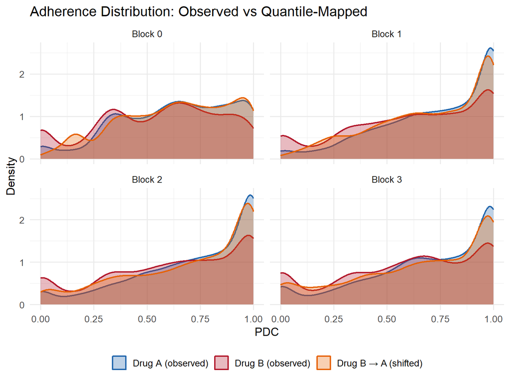

Figure 6: Observed Drug B adherence (red) vs shifted adherence using the conditional quantile map (orange) vs observed Drug A adherence (blue), at each block.

```r
K_max <- max(panel$block)
shift_viz <- list()
for (k in 0:K_max) {
  pdc_col <- paste0("PDC_", k)
  dat_k <- as.data.frame(wide[!is.na(wide[[pdc_col]]), ])

  # Apply shift to see what it produces
  shifted <- shift_qmap_B_to_A(dat_k, pdc_col)

  shift_viz[[length(shift_viz) + 1]] <- data.table(
    block = k,
    group = c(rep("Drug A (observed)", sum(dat_k$A0 == 1)),
              rep("Drug B (observed)", sum(dat_k$A0 == 0)),
              rep("Drug B → A (shifted)", sum(dat_k$A0 == 0))),
    PDC = c(dat_k[[pdc_col]][dat_k$A0 == 1],
            dat_k[[pdc_col]][dat_k$A0 == 0],
            shifted[dat_k$A0 == 0])
  )
}

shift_viz_dt <- rbindlist(shift_viz)

ggplot(shift_viz_dt, aes(x = PDC, fill = group, color = group)) +
  geom_density(alpha = 0.3, linewidth = 0.8) +
  facet_wrap(~paste("Block", block), nrow = 2) +
  scale_fill_manual(values = c("Drug A (observed)" = "#2166AC",
                                "Drug B (observed)" = "#B2182B",
                                "Drug B → A (shifted)" = "#E66100")) +
  scale_color_manual(values = c("Drug A (observed)" = "#2166AC",
                                 "Drug B (observed)" = "#B2182B",
                                 "Drug B → A (shifted)" = "#E66100")) +
  labs(x = "PDC", y = "Density", fill = NULL, color = NULL,
       title = "Adherence Distribution: Observed vs Quantile-Mapped") +
  theme(legend.position = "bottom")
```

The orange (shifted) distribution should closely track the blue (Drug A) distribution. If it does, the quantile mapping successfully transforms Drug B adherence to look like Drug A adherence, conditional on patient characteristics.

### 3.3.4 Step 4: Run LMTP with the quantile-mapping shift

```r
dt_qmap <- as.data.frame(copy(wide))

# Observed outcome for Drug B (no shift, for reference)
fit_B_observed <- lmtp::lmtp_sdr(
  data             = dt_qmap[dt_qmap$A0 == 0, ],
  trt              = trt_nodes,
  outcome          = outcome_nodes,
  baseline         = baseline_nodrug,
  time_vary        = time_vary,
  cens             = cens_nodes,
  shift            = NULL,
  mtp              = FALSE,
  outcome_type     = "survival",
  learners_outcome = sl_lib,
  learners_trt     = sl_lib,
  folds            = 1
)

# Drug B under Drug A adherence distribution (the quantile-mapped shift)
fit_B_shifted <- lmtp::lmtp_sdr(
  data             = dt_qmap[dt_qmap$A0 == 0, ],
  trt              = trt_nodes,
  outcome          = outcome_nodes,
  baseline         = baseline_nodrug,
  time_vary        = time_vary,
  cens             = cens_nodes,
  shift            = shift_qmap_B_to_A,
  mtp              = TRUE,
  outcome_type     = "survival",
  learners_outcome = sl_lib,
  learners_trt     = sl_lib,
  folds            = 1
)

# Drug A under observed (natural) adherence
fit_A_observed <- lmtp::lmtp_sdr(
  data             = dt_qmap[dt_qmap$A0 == 1, ],
  trt              = trt_nodes,
  outcome          = outcome_nodes,
  baseline         = baseline_nodrug,
  time_vary        = time_vary,
  cens             = cens_nodes,
  shift            = NULL,
  mtp              = FALSE,
  outcome_type     = "survival",
  learners_outcome = sl_lib,
  learners_trt     = sl_lib,
  folds            = 1
)

# Contrasts
contrast_shift_vs_obs <- lmtp::lmtp_contrast(fit_B_shifted, ref = fit_B_observed,
                                               type = "additive")

risk_A_obs <- 1 - lmtp_theta(fit_A_observed)
risk_B_obs <- 1 - lmtp_theta(fit_B_observed)
risk_B_shifted <- 1 - lmtp_theta(fit_B_shifted)

ct_qmap <- tidy_contrast(contrast_shift_vs_obs)
cat("=== Quantile-Mapping Results ===\n")
```

```
=== Quantile-Mapping Results ===
```

```r
cat(sprintf("Drug A observed risk:          %.3f\n", risk_A_obs))
```

```
Drug A observed risk:          0.161
```

```r
cat(sprintf("Drug B observed risk:          %.3f\n", risk_B_obs))
```

```
Drug B observed risk:          0.239
```

```r
cat(sprintf("Drug B → A adherence risk:     %.3f\n", risk_B_shifted))
```

```
Drug B → A adherence risk:     0.240
```

```r
cat(sprintf("Effect of matching adherence:  %.3f (%.3f, %.3f)\n",
            ct_qmap$estimate, ct_qmap$conf.low, ct_qmap$conf.high))
```

```
Effect of matching adherence:  -0.000 (-0.001, 0.000)
```

```r
qmap_results <- data.table(
  Estimand = c(
    "Drug A, observed adherence",
    "Drug B, observed adherence",
    "Drug B, Drug A adherence (q-map)",
    "Effect of adherence shift on Drug B",
    "Residual drug difference (Drug A obs - Drug B shifted)"
  ),
  Risk_or_RD = c(
    risk_A_obs,
    risk_B_obs,
    risk_B_shifted,
    ct_qmap$estimate,
    risk_A_obs - risk_B_shifted
  ),
  Interpretation = c(
    "Failure risk on Drug A under natural adherence",
    "Failure risk on Drug B under natural adherence",
    "Failure risk if Drug B patients had Drug A adherence",
    "How much of Drug B's disadvantage is explained by adherence",
    "Drug difference that remains after matching adherence"
  )
)

kable(qmap_results, digits = 3,
      caption = "Decomposing the Drug A vs Drug B comparison using quantile-mapped adherence") |>
  kable_styling(bootstrap_options = c("striped", "hover"), full_width = FALSE)
```

Table 5: Decomposing the Drug A vs Drug B comparison using quantile-mapped adherence

| Estimand | Risk_or_RD | Interpretation |
| --- | --- | --- |
| Drug A, observed adherence | 0.161 | Failure risk on Drug A under natural adherence |
| Drug B, observed adherence | 0.239 | Failure risk on Drug B under natural adherence |
| Drug B, Drug A adherence (q-map) | 0.240 | Failure risk if Drug B patients had Drug A adherence |
| Effect of adherence shift on Drug B | 0.000 | How much of Drug B's disadvantage is explained by adherence |
| Residual drug difference (Drug A obs - Drug B shifted) | -0.078 | Drug difference that remains after matching adherence |

## 3.4 Interpreting the quantile-mapping results

The quantile-mapping analysis decomposes the observed drug difference into two components:

1. **Adherence-mediated component**: How much of Drug B’s higher failure risk is due to its patients having lower adherence? This is the difference between “Drug B observed” and “Drug B under Drug A adherence.”
2. **Residual pharmacologic component**: After matching adherence distributions, how much drug difference remains? This reflects true pharmacologic forgiveness differences that are not explained by adherence patterns.

If the residual difference is small, most of the Drug A advantage comes from better adherence (fewer side effects, better tolerability). If it is large, Drug A has genuinely better pharmacologic forgiveness at equal adherence levels.

This is a causal mediation-like decomposition. The quantile mapping intervenes on the adherence process for Drug B patients, asking “what if their adherence looked like Drug A’s?” while leaving the Drug B pharmacology in place. The remaining drug difference isolates the pharmacologic channel from the adherence channel.

## 3.5 What question does this answer?

The quantile-mapping shift answers:

> If Drug B patients adhered as well as Drug A patients with similar clinical characteristics, how much of Drug B’s higher failure risk would disappear?

This is a **distribution-shift intervention**, not a deterministic static intervention. It does not force all Drug B patients to have PDC = 0.95. Instead, it gives each Drug B patient the adherence level they would most plausibly have had under Drug A, given their age, comorbidities, viral load, and prior adherence. A young, healthy Drug B patient at the 80th percentile of the Drug B distribution gets mapped to the 80th percentile of Drug A — which might be only slightly higher. An older patient with depression at the 30th percentile of Drug B might get a larger shift, because the Drug A advantage in adherence is larger for patients facing more adherence barriers.

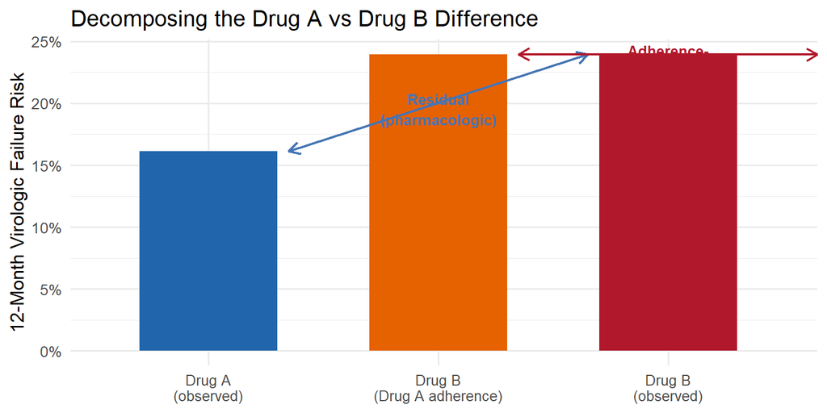

Figure 7: Decomposition of the observed drug difference into adherence-mediated and residual pharmacologic components.

```r
decomp <- data.table(
  Component = factor(c("Drug A\n(observed)",
                        "Drug B\n(Drug A adherence)",
                        "Drug B\n(observed)"),
                     levels = c("Drug A\n(observed)",
                                "Drug B\n(Drug A adherence)",
                                "Drug B\n(observed)")),
  Risk = c(risk_A_obs, risk_B_shifted, risk_B_obs)
)

ggplot(decomp, aes(x = Component, y = Risk, fill = Component)) +
  geom_col(width = 0.6) +
  geom_segment(aes(x = 1.35, xend = 2.65, y = risk_A_obs, yend = risk_B_shifted),
               arrow = arrow(length = unit(0.12, "inches"), ends = "both"),
               color = "#4575B4", linewidth = 0.8) +
  annotate("text", x = 2, y = (risk_A_obs + risk_B_shifted) / 2 - 0.005,
           label = "Residual\n(pharmacologic)", color = "#4575B4", size = 3.5,
           fontface = "bold") +
  geom_segment(aes(x = 2.35, xend = 3.65, y = risk_B_shifted, yend = risk_B_obs),
               arrow = arrow(length = unit(0.12, "inches"), ends = "both"),
               color = "#B2182B", linewidth = 0.8) +
  annotate("text", x = 3, y = (risk_B_shifted + risk_B_obs) / 2 - 0.005,
           label = "Adherence-\nmediated", color = "#B2182B", size = 3.5,
           fontface = "bold") +
  scale_fill_manual(values = c("#2166AC", "#E66100", "#B2182B"), guide = "none") +
  scale_y_continuous(labels = scales::percent) +
  labs(y = "12-Month Virologic Failure Risk", x = NULL,
       title = "Decomposing the Drug A vs Drug B Difference") +
  theme(axis.text.x = element_text(size = 10))
```

# 4 Summary: Comparing Approaches

```r
approaches <- data.table(
  Approach = c(
    "Naive stratification",
    "LMTP +10pp shift (treatment-policy)",
    "LMTP +10pp shift (censor-at-switch)",
    "Quantile-mapping (Drug B → Drug A adherence)"
  ),
  Question = c(
    "Descriptive association between observed adherence and outcome",
    "What if everyone's adherence improved by 10pp, under natural switching/monitoring?",
    "Same, but censoring patients who switch regimens",
    "What if Drug B patients had Drug A's covariate-conditional adherence distribution?"
  ),
  `Handles censoring` = c("No", "Yes", "Yes (extra)", "Yes"),
  `Handles monitoring` = c("No", "Yes (L_t)", "Yes (L_t)", "Yes (L_t)"),
  `Handles switching` = c("No", "Yes (L_t)", "Censors", "Yes (L_t)"),
  `Positivity` = c("N/A", "Good (small shift)", "Good", "Good (within-support)")
)

kable(approaches, caption = "Comparison of estimation approaches") |>
  kable_styling(bootstrap_options = c("striped", "hover"), full_width = FALSE,
                font_size = 12) |>
  column_spec(1, bold = TRUE)
```

Table 6: Comparison of estimation approaches

| Approach | Question | Handles censoring | Handles monitoring | Handles switching | Positivity |
| --- | --- | --- | --- | --- | --- |
| Naive stratification | Descriptive association between observed adherence and outcome | No | No | No | N/A |
| LMTP +10pp shift (treatment-policy) | What if everyone's adherence improved by 10pp, under natural switching/monitoring? | Yes | Yes (L_t) | Yes (L_t) | Good (small shift) |
| LMTP +10pp shift (censor-at-switch) | Same, but censoring patients who switch regimens | Yes (extra) | Yes (L_t) | Censors | Good |
| Quantile-mapping (Drug B → Drug A adherence) | What if Drug B patients had Drug A's covariate-conditional adherence distribution? | Yes | Yes (L_t) | Yes (L_t) | Good (within-support) |

The naive analysis ignores all informative processes and produces biased estimates. The additive LMTP shift is a clean, interpretable intervention that answers “what if everyone adhered a bit better?” The quantile-mapping approach answers the more targeted question of whether Drug B’s disadvantage is driven by adherence differences or pharmacologic differences. In practice, these are complementary analyses: the additive shift quantifies the benefit of an adherence intervention, while the quantile mapping decomposes the drug comparison.

## 4.1 Consolidated bias summary

```r
# Compute naive estimates to compare against oracle
naive_res <- estimate_naive(panel, K_blocks = K_blocks)

# Map naive adherence categories to approximate PDC values for oracle lookup
naive_pdc_map <- c(low = 0.35, medium = 0.65, high = 0.90)

naive_bias <- list()
if (!is.null(naive_res$risks)) {
  for (i in seq_len(nrow(naive_res$risks))) {
    row <- naive_res$risks[i, ]
    cat_label <- as.character(row$adh_cat)
    approx_pdc <- naive_pdc_map[cat_label]
    drug_label <- ifelse(row$A0 == 1, "Drug A", "Drug B")

    oracle_val <- oracle[a0 == row$A0 & abs(adh_target - approx_pdc) < 0.06, cum_risk]
    if (length(oracle_val) > 0) oracle_val <- oracle_val[1] else oracle_val <- NA

    naive_bias[[length(naive_bias) + 1]] <- data.table(
      Estimator = "Naive",
      Drug      = drug_label,
      PDC       = approx_pdc,
      Estimate  = row$risk,
      Oracle    = oracle_val,
      Bias      = row$risk - oracle_val
    )
  }
}
naive_bias_dt <- rbindlist(naive_bias)
```

```r
# Combine LMTP-static and naive bias
all_bias <- rbind(
  static_bias_dt[, .(Estimator = "LMTP-static", Drug, PDC, Estimate, Oracle, Bias)],
  naive_bias_dt[, .(Estimator, Drug, PDC, Estimate, Oracle, Bias)],
  fill = TRUE
)

kable(all_bias[order(PDC, Drug, Estimator)], digits = 4,
      caption = "Bias comparison: LMTP-static vs Naive at comparable adherence levels") |>
  kable_styling(bootstrap_options = c("striped", "hover"), full_width = FALSE)
```

Table 7: Bias comparison: LMTP-static vs Naive at comparable adherence levels

| Estimator | Drug | PDC | Estimate | Oracle | Bias |
| --- | --- | --- | --- | --- | --- |
| LMTP-static | Drug A | 0.50 | 0.1590 | 0.0400 | 0.1190 |
| LMTP-static | Drug A | 0.50 | 0.1590 | 0.0316 | 0.1273 |
| LMTP-static | Drug B | 0.50 | 0.2386 | 0.0400 | 0.1986 |
| LMTP-static | Drug B | 0.50 | 0.2386 | 0.0316 | 0.2070 |
| LMTP-static | Drug A | 0.70 | 0.1624 | 0.0248 | 0.1376 |
| LMTP-static | Drug A | 0.70 | 0.1624 | 0.0226 | 0.1398 |
| LMTP-static | Drug B | 0.70 | 0.2312 | 0.0248 | 0.2064 |
| LMTP-static | Drug B | 0.70 | 0.2312 | 0.0226 | 0.2086 |
| LMTP-static | Drug A | 0.80 | 0.1658 | 0.0202 | 0.1455 |
| LMTP-static | Drug A | 0.80 | 0.1658 | 0.0196 | 0.1462 |
| LMTP-static | Drug B | 0.80 | 0.2278 | 0.0202 | 0.2076 |
| LMTP-static | Drug B | 0.80 | 0.2278 | 0.0196 | 0.2082 |
| LMTP-static | Drug A | 0.90 | 0.1673 | 0.0168 | 0.1506 |
| LMTP-static | Drug A | 0.90 | 0.1673 | 0.0172 | 0.1501 |
| LMTP-static | Drug B | 0.90 | 0.2210 | 0.0168 | 0.2042 |
| LMTP-static | Drug B | 0.90 | 0.2210 | 0.0172 | 0.2038 |
| LMTP-static | Drug A | 0.95 | 0.1674 | 0.0153 | 0.1521 |
| LMTP-static | Drug A | 0.95 | 0.1674 | 0.0162 | 0.1513 |
| LMTP-static | Drug B | 0.95 | 0.2208 | 0.0153 | 0.2056 |
| LMTP-static | Drug B | 0.95 | 0.2208 | 0.0162 | 0.2047 |
| Naive | Drug A | NA | 0.1497 | NA | NA |
| Naive | Drug A | NA | 0.2028 | NA | NA |
| Naive | Drug A | NA | 0.1232 | NA | NA |
| Naive | Drug A | NA | 0.1284 | NA | NA |
| Naive | Drug B | NA | 0.2181 | NA | NA |
| Naive | Drug B | NA | 0.2812 | NA | NA |
| Naive | Drug B | NA | 0.1660 | NA | NA |
| Naive | Drug B | NA | 0.1644 | NA | NA |

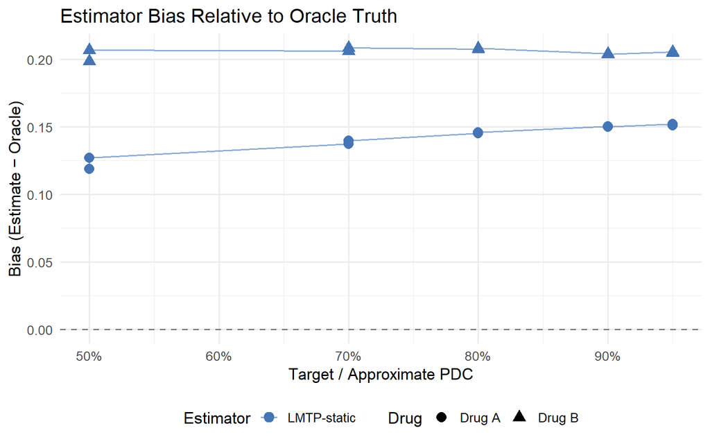

```r
if (nrow(all_bias[!is.na(Bias)]) > 0) {
  ggplot(all_bias[!is.na(Bias)],
         aes(x = PDC, y = Bias, color = Estimator, shape = Drug)) +
    geom_hline(yintercept = 0, linetype = "dashed", color = "grey50") +
    geom_point(size = 3.5) +
    geom_line(aes(group = interaction(Estimator, Drug)), linewidth = 0.7, alpha = 0.6) +
    scale_x_continuous(labels = scales::percent) +
    scale_color_manual(values = c("LMTP-static" = "#4575B4", "Naive" = "#D73027")) +
    labs(x = "Target / Approximate PDC", y = "Bias (Estimate − Oracle)",
         title = "Estimator Bias Relative to Oracle Truth") +
    theme(legend.position = "bottom")
}
```